# Chapter 11 Exercises

## Mar. 6. 2020

```python
import numpy as np
import pandas as pd
import matplotlib.pyplot as plt
```

## Preliminaries: Putting the ISLM Curve into Python

The IS curve is a simple linear function! However, incorporating the formula $\tilde{Y_t}=\bar{a}-\bar{b}(R_t-\bar{r})$ into Python can be a little tricky because $R_t$ is the dependent variable, not the independent variable when we are graphing it on the Carthesian plane. If I was doing this homework, these are the steps I would take to graph the IS curve:

- Solve for $R_t$ in this equation $\tilde{Y_t}=\bar{a}-\bar{b}(R_t-\bar{r})$.
- Create an array that contains the range of $\tilde{Y}_t$: $\left(-\bar{a}-\bar{b}\bar{r}, \;\bar{a}+\bar{b}\bar{r}\right)$.
- Use the formula mentioned in bulletpoint 1 to calculate the corresponding values for $R_t$.
- Graph it! Use the appropriate labeling of values of the x-axis so it looks right.

R_t = (a - Y_st) / b + r\ Y_st = [-a-b*r, a + b*r] range\ y-axis: real interest rate(Rt), x-axis: Y_st

## Q1) Analyzing Macroeconomic Events with the IS Curve (I)

Assuming that the initial parameters for the IS curve are: $\bar{a}=0$, $\bar{b}=3$, and $\bar{r}=2$, analyze the effect of each event below on the IS curve. Your answers should include a plot with two IS curves. The first showing the IS curve under the initial parameters, and a second showing a new IS curve resulting of the event proposed below. Please provide an explanation of your plot. *Hint: This question was solved in your book. Check at the end of chapter questions.*

**(a)** The Federal Reserve undertakes policy actions that have the effect of lowering the real interest rate below the marginal product of captial. *Hint: there might not be two IS for this question*

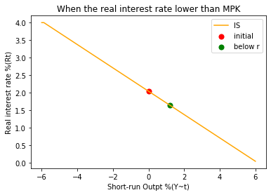

```python
a = 0
b = 3
r = 2
i = 0

Y_st = np.linspace(-a - b*r, a + b*r, 101)
R_t = (((a - Y_st[i]) / b) + r)

for i in range(0, 100):
    R_t = np.append(R_t, ((a - Y_st[i]) / b) + r)

plt.plot(Y_st, R_t, "orange", label = "IS")
plt.title("When the real interest rate lower than MPK")
plt.xlabel("Short-run Outpt %(Y~t)")
plt.ylabel("Real interest rate %(Rt)")
plt.scatter(Y_st[50], R_t[50], s=50, c = "red", label = "initial")
plt.scatter(Y_st[60], R_t[60] ,s=50, c = "green", label = "below r")
plt.legend()
plt.show()
```

Becuase the real interest is endogenous variable, a point moves long the curve if the real interest rate changes. Because the real interest rate is lower than MPK = 2, short-run output is over 0 percent becuase people invest more.

**(b)** Consumers become pessimistic about the state of the economy and future productivity growth.

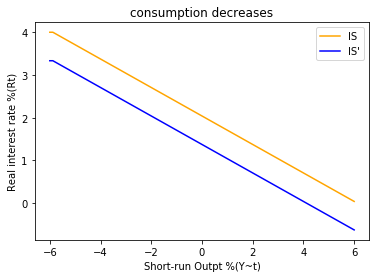

```python
a = 0
b = 3
r = 2
i = 0

Y_st = np.linspace(-a - b*r, a + b*r, 100)
R_t = ((a - Y_st[i]) / b) + r

for i in range(0, 99):
    R_t = np.append(R_t, ((a - Y_st[i]) / b) + r)

a = -2
b = 3
r = 2
i = 0

R_t1 = ((a - Y_st[i]) / b) + r
for i in range(0, 99):
    R_t1 = np.append(R_t1, ((a - Y_st[i]) / b) + r)


plt.plot(Y_st, R_t, "orange", label = "IS")
plt.plot(Y_st, R_t1, "blue", label = "IS'")
plt.title("consumption decreases")
plt.xlabel("Short-run Outpt %(Y~t)")
plt.ylabel("Real interest rate %(Rt)")
plt.legend()
plt.show()
```

Becuase the consumers became pessimistic, one of the components of a, a_c, is becoming lower than before. So a is becoming smaller than 0. a = a_c + a_i + a_g + a_ex + a_im - 1. So the IS curve shifts to the left, which will decrease the short-run output with the same real interest rate.

**(c)** Improvements in information technology increase productivity and therefore increase the marginal product of capital.

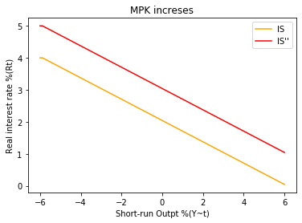

```python
a = 0
b = 3
r = 2
i = 0

Y_st = np.linspace(-a - b*r, a + b*r, 100)
R_t = ((a - Y_st[i]) / b) + r

for i in range(0, 99):
    R_t = np.append(R_t, ((a - Y_st[i]) / b) + r)

a = 0
b = 3
r = 3
i = 0

R_t2 = ((a - Y_st[i]) / b) + r
for i in range(0, 99):
    R_t2 = np.append(R_t2, ((a - Y_st[i]) / b) + r)

plt.plot(Y_st, R_t, "orange", label = "IS")
plt.plot(Y_st, R_t2, "red", label = "IS''")
plt.title("MPK increses")
plt.xlabel("Short-run Outpt %(Y~t)")
plt.ylabel("Real interest rate %(Rt)")
plt.legend()
plt.show()
```

Because of a new technology, the IS curve shitfs out. With the same real interest rate, short-run output is bigger than before. And if increase in MPK becomes high relative to the real interest rate, investment will raise too.

## Q2) Analyzing Macroeconomic Events with the IS Curve (II)

Assuming that the initial parameters for the IS curve are: $\bar{a}=0$, $\bar{b}=3$, and $\bar{r}=2$, analyze the effect of each event below on the IS curve. Show how to think about them using the IS curve, and explain how and why GDP is affected in the short run.

**(a)** The government offers a temporary investment tax credit: for each dollar of investment that firms undertake, they recieve a credit that reduces the taxes they pay on corporate income.

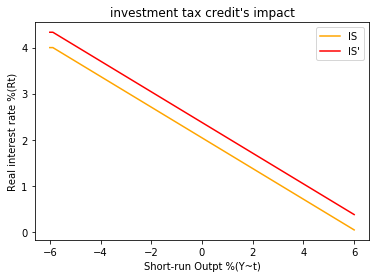

```python
a = 0
b = 3
r = 2
i = 0

Y_st = np.linspace(-a - b*r, a + b*r, 100)
R_t = ((a - Y_st[i]) / b) + r

for i in range(0, 99):
    R_t = np.append(R_t, ((a - Y_st[i]) / b) + r)

a = 1
b = 3
r = 2
i = 0
R_t3 = ((a - Y_st[i]) / b) + r

for i in range(0, 99):
    R_t3 = np.append(R_t3, ((a - Y_st[i]) / b) + r)


plt.plot(Y_st, R_t, "orange", label = "IS")
plt.plot(Y_st, R_t3, "red", label = "IS'")
plt.title("investment tax credit's impact")
plt.xlabel("Short-run Outpt %(Y~t)")
plt.ylabel("Real interest rate %(Rt)")
plt.legend()
plt.show()
```

Because of the new tax program, firms will invest now more than the future to take the advantage of the new tax program. So, a will increase over 0 because a_i increase which is a component of a. So in the Yt = Y_t + Y_st, Y_st increases above 0, actual output(Yt) will be above of potential output(Y_t).

**(b)** A booming economy in Europe this year leads to an unexpected increase in the demand by European consumers for US goods.

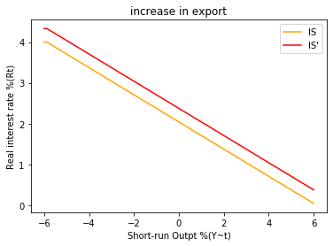

```python
a = 0
b = 3
r = 2
i = 0

Y_st = np.linspace(-a - b*r, a + b*r, 100)
R_t = ((a - Y_st[i]) / b) + r

for i in range(0, 99):
    R_t = np.append(R_t, ((a - Y_st[i]) / b) + r)

a = 1
b = 3
r = 2
i = 0
R_t4 = ((a - Y_st[i]) / b) + r

for i in range(0, 99):
    R_t4 = np.append(R_t4, ((a - Y_st[i]) / b) + r)


plt.plot(Y_st, R_t, "orange", label = "IS")
plt.plot(Y_st, R_t4, "red", label = "IS'")
plt.title("increase in export")
plt.xlabel("Short-run Outpt %(Y~t)")
plt.ylabel("Real interest rate %(Rt)")
plt.legend()
plt.show()
```

The export increases. One of the components of a, a_ex increases. The IS curve shifts out. So in the same real interest rate, short-run output increases.

**(c)** US consumers develop an infatuation with all things made in New Zealand and sharply increase their imports from that country.

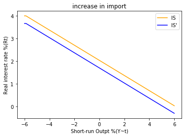

```python
a = 0
b = 3
r = 2
i = 0

Y_st = np.linspace(-a - b*r, a + b*r, 100)
R_t = ((a - Y_st[i]) / b) + r

for i in range(0, 99):
    R_t = np.append(R_t, ((a - Y_st[i]) / b) + r)

a = -1
b = 3
r = 2
i = 0
R_t5 = ((a - Y_st[i]) / b) + r

for i in range(0, 99):
    R_t5 = np.append(R_t5, ((a - Y_st[i]) / b) + r)


plt.plot(Y_st, R_t, "orange", label = "IS")
plt.plot(Y_st, R_t5, "blue", label = "IS'")
plt.title("increase in import")
plt.xlabel("Short-run Outpt %(Y~t)")
plt.ylabel("Real interest rate %(Rt)")
plt.legend()
plt.show()
```

Because of increased import, one of the components a, a_im, increases which is negative to the short-run output. The IS curve shifts in, and with every real interest rate short-run output is smaller than before.

**(d)** A housing bubble bursts so that housing prices fall by 20% and new home sales drop sharply.

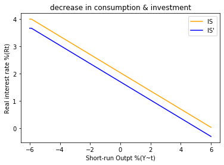

```python
a = 0
b = 3
r = 2
i = 0

Y_st = np.linspace(-a - b*r, a + b*r, 100)
R_t = ((a - Y_st[i]) / b) + r

for i in range(0, 99):
    R_t = np.append(R_t, ((a - Y_st[i]) / b) + r)

a = -1
b = 3
r = 2
i = 0
R_t6 = ((a - Y_st[i]) / b) + r

for i in range(0, 99):
    R_t6 = np.append(R_t6, ((a - Y_st[i]) / b) + r)


plt.plot(Y_st, R_t, "orange", label = "IS")
plt.plot(Y_st, R_t6, "blue", label = "IS'")
plt.title("decrease in consumption & investment")
plt.xlabel("Short-run Outpt %(Y~t)")
plt.ylabel("Real interest rate %(Rt)")
plt.legend()
plt.show()
```

House price drop will make consumers less consume in general and less investment to the house. So the two components of a, a_c & a_i, decrease, which make short-run output decrease to the every real interest rate.

## Q3) Imports and the Multiplier

The amount of goods that the US economy imports might depend on the current state of the economy as well as on potential GDP. For example, when the economy is booming, imports usually rise. To incorporate this channel into the model, suppose the import equation is given by

\begin{align*} \frac{IM_t}{\bar{Y_t}} = \bar{a_{im}} + \bar{n}\tilde{Y_{t}}. \end{align*}

Assume the remainder of the model is unchanged from the original setup, as in Table 11.1 (pg. 283)

**(a)** Derive and graph the IS curve for this new specification. Write your answers below

Y_st = (1 / (1 - n)) *(a - b*(Rt - r))\ R_t = ((Y_st * (1 - n) - a) / -b) + r

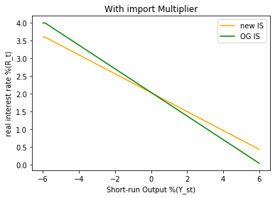

```
(1 - n) / b is smaller than 1/ b so the slope is flatter
```

```python
a = 0
b = 3
r = 2
n = 0.2
i = 0

Y_st1 = np.linspace(-(a + b*r), a + b*r , 100)
Rt_8 = ((a - Y_st1[i]) / b) + r

for i in range(0, 99):
    Rt_8 = np.append(Rt_8, ((a - Y_st1[i]) / b) + r)

a = 0
b = 3
r = 2
n = 0.2
i = 0

Rt_im = ((a - (Y_st1[i] * (1 - n))) / b) + r

for i in range(0, 99):
    Rt_im = np.append(Rt_im, ((a - (Y_st1[i] * (1 - n))) / b) + r)

plt.plot(Y_st1, Rt_im, "orange", label = "new IS")
plt.plot(Y_st1, Rt_8, "green", label = "OG IS")
plt.title("With import Multiplier")
plt.xlabel("Short-run Output %(Y_st)")
plt.ylabel("real interest rate %(R_t)")
plt.legend()
plt.show()

print("(1 - n) / b is smaller than 1/ b so the slope is flatter")
```

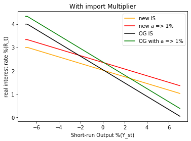

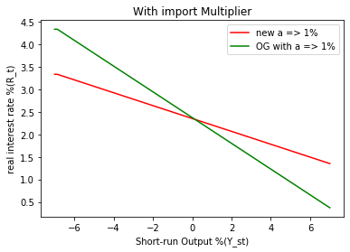

```python
a = 0
b = 3
r = 2
n = 0.5     ##### I put n = 0.5 to see more drastic example
i = 0

Rt_im = ((a - (Y_st1[i] * (1 - n))) / b) + r

for i in range(0, 99):
    Rt_im = np.append(Rt_im, ((a - (Y_st1[i] * (1 - n))) / b) + r)

a = 1
b = 3
r = 2
n = 0.5
i = 0

Y_st2 = np.linspace(-(a + b*r), a + b*r , 100)

Rt_im1 = ((a - (Y_st1[i] * (1 - n))) / b) + r
for i in range(0, 99):
    Rt_im1 = np.append(Rt_im1,((a - (Y_st1[i] * (1 - n))) / b) + r)

c = 1
b = 3
r = 2
n = 0.2
i = 0

Rt_11 = ((c - Y_st1[i]) / b) + r

for i in range(0, 99):
    Rt_11 = np.append(Rt_11, ((c - Y_st1[i]) / b) + r)

plt.plot(Y_st2, Rt_im, "orange", label = "new IS")
plt.plot(Y_st2, Rt_im1, "red", label = "new a => 1%")
plt.plot(Y_st2, Rt_8, "black", label = "OG IS")
plt.plot(Y_st2, Rt_11, "green", label = "OG with a => 1%")
plt.title("With import Multiplier")
plt.xlabel("Short-run Output %(Y_st)")
plt.ylabel("real interest rate %(R_t)")
plt.legend()
plt.show()

plt.plot(Y_st2, Rt_im1, "red", label = "new a => 1%")
plt.plot(Y_st2, Rt_11, "green", label = "OG with a => 1%")
plt.title("With import Multiplier")
plt.xlabel("Short-run Output %(Y_st)")
plt.ylabel("real interest rate %(R_t)")
plt.legend()
plt.show()
```

**(c)** What is the economic explanation for why the $\bar{n}$ parameter shows up in the denominator of the new IS curve? Notice that an aggregate demand shock that increases $\bar{a}$ by 1 percentage point now has a *smaller* effect on output than it did in the original IS curve. Why?

Original is Y_st, but the new formula is (1 - n)*Y_st. So the new formula's short-run output is smaller.\ But my question is that the slope is flatter than the original one, so with the same interest rate the new slope is having bigger short-run output\ n is between 0 and 1.\ 1 - n is the the denominator for the new IS curve which gives multiplier effect. In this case the new short-run output is bigger than the old short-run output.\ Actually, n is making bigger effect on 'a' which makes gibber effect on output. For example, 1/0.8 = 10/8, this is making 'a' bigger, so the new short-run output gets bigger.\ I can see that becuase the slope is flatter, the change in short-run output by change in interest rate is bigger too.

new short-run output = (1 / (1-n)) * (a - b(Rt-r))

## Q4) Consumption and the Real Interest Rate

According to the life-cycle/permanent-income hypothesis, consumption depends on the present dicounted value of income. An increase in the real interest rate will make future income worth less, thereby reducing the present discounted value and reducing consumption. To incorporate this channel into the model, suppose the consumption equation is given by

\begin{align*} C_t = \bar{a_c}\bar{Y_t}-\bar{b_c}(R_t-\bar{r})\bar{Y_t} \end{align*}

Assume the remainder of the model is unchanged from the original setup, as in Table 11.1 (pg. 283)

**(a)** Derive and graph the IS curve for this new specification. Write your answers below

Y_st = a -(b + b_c) * (Rt - r)\ Rt = ((a - Y_st) / (b + b_c)) + r\ becoming flatter slope because b became bigger

**(b)** Assuming that the parameters for the IS curve are: $\bar{a}=0$, $\bar{b}_i=3$, $\bar{b}_c=1$, and $\bar{r}=2$. Plot both the original IS curve next to the new version of the IS curve from this question.

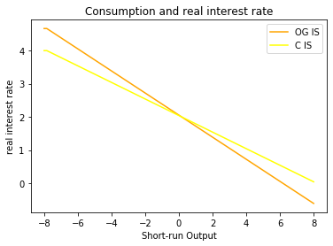

```python
a = 0
b = 3
b_c = 1
r = 2
i = 0

Y_st = np.linspace(-(a + (b+b_c)*r), a + (b+b_c)*r, 100)
R_to = ((a - Y_st[i]) / b) + r

for i in range(0, 99):
    R_to = np.append(R_to, ((a - Y_st[i]) / b) + r)

a = 0
b = 3
b_c = 1
r = 2
i = 0

R_tc = ((a - Y_st[i]) / (b + b_c)) + r
for i in range(0, 99):
    R_tc = np.append(R_tc, ((a - Y_st[i]) / (b + b_c)) + r)

plt.plot(Y_st, R_to, "orange", label = "OG IS")
plt.plot(Y_st, R_tc, "yellow", label = "C IS")
plt.title("Consumption and real interest rate")
plt.xlabel("Short-run Output")
plt.ylabel("real interest rate")
plt.legend()
plt.show()
```

**(c)** How and why does it differ from the original IS curve? (*Hint:* Think about the slope of the IS curve)

The slope is becoming flatter becuase (b + b_c) as a total b is becoming bigger.\ The slope 1 / (b + b_c) is smaller than 1 / b

## Q5) GDP and Government Purchases (FRED)

**(a)** Using data from Fred, create a time-series graph showing Real GDP and Real Government Purchases for the period 2004 to the present. *Hint: Make sure that the series you select for your graph are the same frequency, base year, and units as each other.*

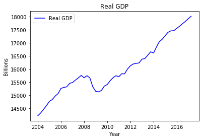

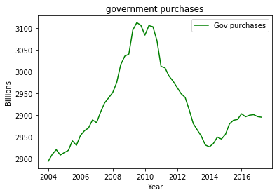

```python
# Insert your Python code here:
gov = pd.read_csv(r"C:\Users\Jae\Desktop\Econ 381\homework\W09\GCEC96(gov pur).csv", header = 0, names = ["Date", "GOV"])
Real = pd.read_csv(r"C:\Users\Jae\Desktop\Econ 381\homework\W09\GDPC1(real GDP).csv", header = 0, names = ["Date", "REAL"])

Yr = []
i = 0
for i in range(0, 54):
    Yr = np.append(Yr, gov["Date"][i])

gov_pur = []
i = 0
for i in range(0, 54):
    gov_pur = np.append(gov_pur, gov["GOV"][i])

Yt = []
i = 0
for i in range(0, 54):
    Yt = np.append(Yt, Real["REAL"][i])

df = pd.DataFrame({"Year": Yr, "Real GDP": Yt, "Government Purchases": gov_pur}, columns = ["Year", "Real GDP", "Government Purchases"])
df["Year"] = np.array(df["Year"], dtype = np.datetime64)
df

plt.plot(df["Year"], df["Real GDP"], "blue", label = "Real GDP")
plt.title("Real GDP")
plt.xlabel("Year")
plt.ylabel("Billions")
plt.legend()
plt.show()

plt.plot(df["Year"], df["Government Purchases"], "green", label = "Gov purchases")
plt.title("government purchases")
plt.xlabel("Year")
plt.ylabel("Billions")
plt.legend()
plt.show()
```

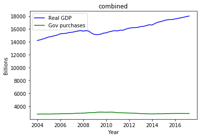

```python
plt.plot(df["Year"], df["Real GDP"], "blue", label = "Real GDP")
plt.plot(df["Year"], df["Government Purchases"], "green", label = "Gov purchases")
plt.title("combined")
plt.xlabel("Year")
plt.ylabel("Billions")
plt.legend()
plt.show()
```

[figure not shown]

```python
com = pd.read_csv(r"C:\Users\Jae\Desktop\Econ 381\homework\W09\fredgraph(combined).csv", header = 0, names = ["Date","GV","GDP"])

date = np.array(com["Date"], dtype = np.datetime64)
gv = np.array(com["GV"])
gdp = np.array(com["GDP"])

plt.plot(date, gv)
plt.plot(date, gdp)
plt.show()
```

**(b)** How did government purchases and real GDP co-move during and after the Great Recession?

**(c)** Provide two alternative (and conflicting!) interpretations of these data, one suggesting that the rise in government purchases had a negative effect on the economy, and the other suggesting it had a positive effect.

(1) Becuase government used lots of money in the country so the interest rate went up from the short of money to lend out to the companies in the country which cuased 'crowded out'. So the investment went down. This makes IS curve shifts in. Then short-run output is negative which makes the actual output below the potential output.\ (2) When the government purchases rise, one of the components of a, a_g increases. The Short-run output rises which will make the IS curve will shift out. And rised short-run output will make actual output above the potential output.

But the real GDP is fallen in this case.

**(d)** Why is it difficult to determine which of these stories is most appropriate?

Becuase we don't know well how much the economy might move by changing the components of 'a'. And the components of a is not working indivisually. The components are mutually related. When one component of 'a' changes the other components change too, but not always in the same direction.